# Experimental Design and Probability

## Examples from Whitlock and Schluter, 2015

```r
# Set the web address where R will look for files from this repository
repo_url <- "https://raw.githubusercontent.com/elahi/xdp/master/data/"
```

## Example: Knees who say night

Wright and Czeisler (2002)

Does the application of 3 hours of bright light to the backs of your *knees* cause a shift in your circadian rhythm (measured as melatonin production)?

```r
dat <- read_csv(paste(repo_url, "chap15e1KneesWhoSayNight.csv", sep = ""))
head(dat)
```

```
## # A tibble: 6 x 2
##   treatment shift
##   <chr>     <dbl>
## 1 control    0.53
## 2 control    0.36
## 3 control    0.2
## 4 control   -0.37
## 5 control   -0.6
## 6 control   -0.64
```

## Example: Knees who say night

```r
grand_mean <- mean(dat$shift)
dat_summary <- dat %>%
  group_by(treatment) %>%
  summarise(mean = mean(shift),
            sd = sd(shift),
            n = n())
dat_summary
```

```
## # A tibble: 3 x 4
##   treatment   mean    sd     n
##   <chr>      <dbl> <dbl> <int>
## 1 control   -0.309 0.618     8
## 2 eyes      -1.55  0.706     7
## 3 knee      -0.336 0.791     7
```

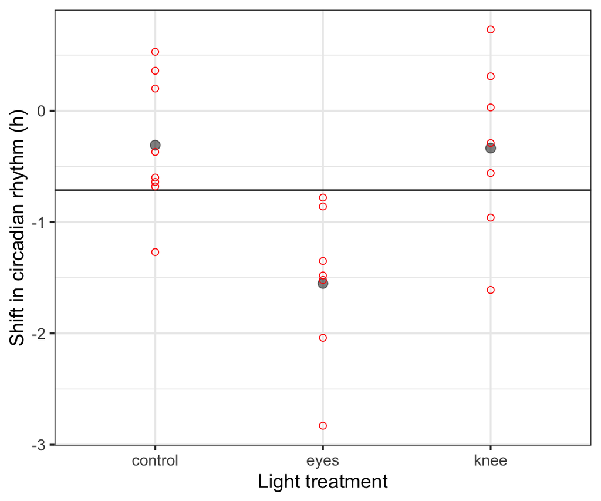

```r
aov1 <- aov(shift ~ treatment, data = dat)
summary(aov1)
```

```
##             Df Sum Sq Mean Sq F value  Pr(>F)
## treatment    2  7.224   3.612   7.289 0.00447 **
## Residuals   19  9.415   0.496
## ---
## Signif. codes:  0 '***' 0.001 '**' 0.01 '*' 0.05 '.' 0.1 ' ' 1
```

## Variation explained: \(R^2\)

\[ \begin{aligned} R^2 = \frac{SS_{groups}}{SS_{total}}\\ \end{aligned} \]

```r
str(summary(aov1))
```

```
## List of 1
##  $ :Classes 'anova' and 'data.frame':    2 obs. of  5 variables:
##   ..$ Df     : num [1:2] 2 19
##   ..$ Sum Sq : num [1:2] 7.22 9.42
##   ..$ Mean Sq: num [1:2] 3.612 0.496
##   ..$ F value: num [1:2] 7.29 NA
##   ..$ Pr(>F) : num [1:2] 0.00447 NA
##  - attr(*, "class")= chr [1:2] "summary.aov" "listof"
```

## Variation explained: \(R^2\)

```r
ss <- summary(aov1)[[1]]$"Sum Sq"; ss
```

```
## [1] 7.224492 9.415345
```

```r
ss_total <- sum(ss); ss_total
```

```
## [1] 16.63984
```

```r
ss_groups <- ss[1]; ss_groups
```

```
## [1] 7.224492
```

```r
r2 <- ss_groups / ss_total; r2
```

```
## [1] 0.4341684
```

## Robustness to assumptions

1. Observations are independent ***
2. Variance is ~equal in all \(k\) groups **
3. Data are normally distributed in all \(k\) groups *

What if 2 & 3 cannot be met?

Try nonparametric method based on ranks: *Kruskal-Wallis* test.

## Kruskal-Wallis test

```r
kruskal.test(shift ~ as.factor(treatment), data = dat)
```

```
##
##  Kruskal-Wallis rank sum test
##
## data:  shift by as.factor(treatment)
## Kruskal-Wallis chi-squared = 9.4231, df = 2, p-value = 0.008991
```

## Life after ANOVA

Planned comparisons (*a priori*)

- You *planned* a comparison *before* doing the experiment
- You can do the specific pairwise comparison, no matter the outcome of the ANOVA
- Same assumptions as ANOVA, but not as robust

Unplanned comparisons (*post hoc*)

- If you reject the \(H_0\), can test for all pairwise differences
- Tukey-Kramer (i.e., Tukey's HSD) test uses a modified t-distribution to correct for multiple tests
- conservative test

## Planned comparisons

*A priori*, we were particularly interested in the knee treatment vs control groups.

\[ \begin{aligned} SE = \sqrt{MS_{error} (1/n_1 + 1/n_2)} \\ \end{aligned} \]

Use t-distribution with \(N - k\) degrees of freedom.

```r
ms <- summary(aov1)[[1]]$"Mean Sq"; ms
```

```
## [1] 3.6122459 0.4955445
```

```r
se_pooled <- sqrt(ms[2] * (1/dat_summary$n[3] + 1/dat_summary$n[1])); se_pooled
```

```
## [1] 0.3643283
```

## Planned comparisons

```r
x_diff <- dat_summary$mean[3] - dat_summary$mean[1] # knee - control
N <- dim(dat)[1]; k <- length(unique(dat$treatment))
t_value <- x_diff / se_pooled; t_value
```

```
## [1] -0.07401095
```

```r
pt(q = t_value, df = N - k, lower.tail = FALSE)
```

```
## [1] 0.5291123
```

If you do > 1 planned comparison, consider adjusting \(\alpha\), e.g., using Bonferroni correction. But you can do no more than \(k - 1\) planned comparisons!

## Unplanned comparisons

```r
TukeyHSD(aov1)
```

```
##   Tukey multiple comparisons of means
##     95% family-wise confidence level
##
## Fit: aov(formula = shift ~ treatment, data = dat)
##
## $treatment
##                     diff        lwr        upr     p adj
## eyes-control -1.24267857 -2.1682364 -0.3171207 0.0078656
## knee-control -0.02696429 -0.9525222  0.8985936 0.9969851
## knee-eyes     1.21571429  0.2598022  2.1716263 0.0116776
```

## Unplanned comparisons

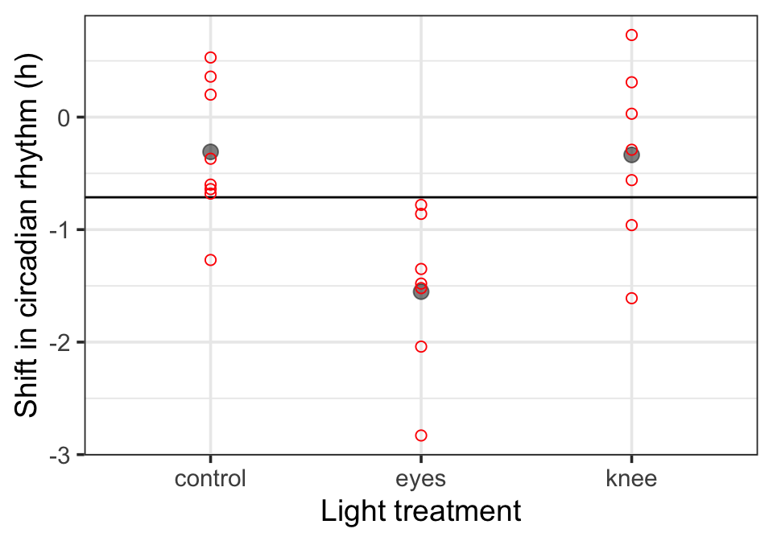

## Fixed vs. random effects

Model 1 ANOVA: fixed effects

- groups are *predetermined*
- if you did the study again, you would use the same groups
- you wish for more replication within groups (larger \(n\)), but not more groups (\(k\))

Model 2 ANOVA: random effects

- groups are chosen *randomly*
- if you did the study again, you would use a different sample of groups
- you wish for more groups (larger \(k\))

## Example: walking-stick limbs

Nosil and Crespi (2006)

How repeatable are measurements of femur lengths from the photographs of walking sticks?

```r
dat <- read_csv(paste(repo_url, "chap15e6WalkingStickFemurs.csv", sep = ""))
```

## Example: walking-stick limbs

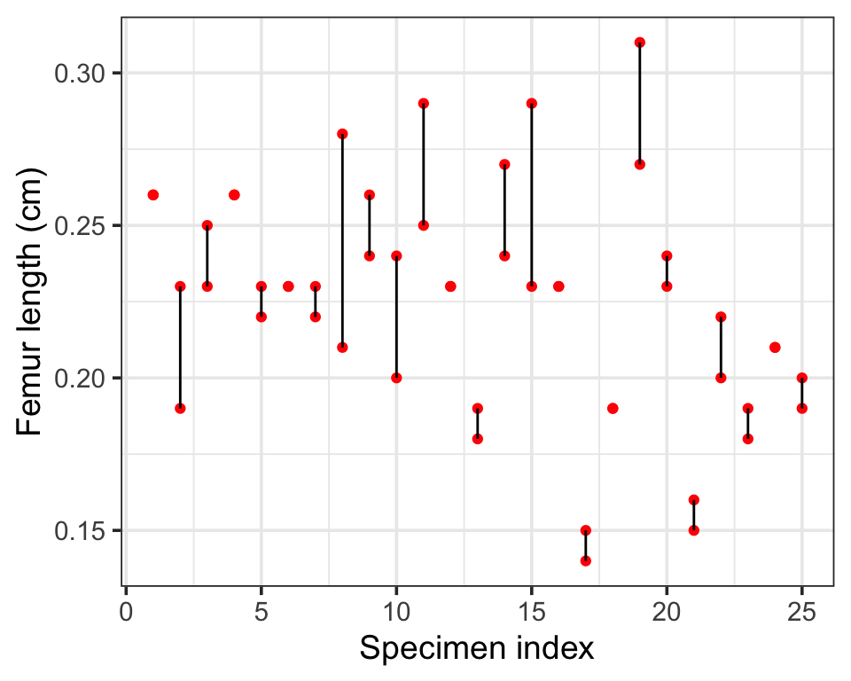

## Fixed effects analysis

```r
glimpse(dat) # note that specimen is NOT a character or factor
```

```
## Observations: 50
## Variables: 2
## $ specimen    <int> 1, 1, 2, 2, 3, 3, 4, 4, 5, 5, 6, 6, 7, 7, 8, 8, 9, 9…
## $ femurLength <dbl> 0.26, 0.26, 0.23, 0.19, 0.25, 0.23, 0.26, 0.26, 0.23…
```

```r
aov1 <- aov(femurLength ~ specimen, data = dat)
summary(aov1)
```

```
##             Df  Sum Sq  Mean Sq F value  Pr(>F)
## specimen     1 0.01020 0.010201   8.467 0.00547 **
## Residuals   48 0.05783 0.001205
## ---
## Signif. codes:  0 '***' 0.001 '**' 0.01 '*' 0.05 '.' 0.1 ' ' 1
```

Something is fishy with the df here…

## Fixed effects analysis

```r
dat$specimen <- as.character(dat$specimen)
aov1 <- aov(femurLength ~ specimen, data = dat)
summary(aov1)
```

```
##             Df  Sum Sq  Mean Sq F value   Pr(>F)
## specimen    24 0.05913 0.002464   6.921 4.08e-06 ***
## Residuals   25 0.00890 0.000356
## ---
## Signif. codes:  0 '***' 0.001 '**' 0.01 '*' 0.05 '.' 0.1 ' ' 1
```

## Random effects analysis

Two sources of random variation: within AND among groups

```r
aov2 <- aov(femurLength ~ Error(specimen), data = dat)
summary(aov2)
```

```
##
## Error: specimen
##           Df  Sum Sq  Mean Sq F value Pr(>F)
## Residuals 24 0.05913 0.002464
##
## Error: Within
##           Df Sum Sq  Mean Sq F value Pr(>F)
## Residuals 25 0.0089 0.000356
```

## Variance components

Variation within groups

- \(MS_{error}\) is the best estimate of \(\sigma^2\)
- variance among repeat measurements of femur length

Variation among groups

- assumed to be distributed normally with
- grand mean \(\mu_A\) (mean of group means)
- variance \(\sigma_A^2\) (variance of group means)

## Estimating \(\sigma_A^2\) with \(s_A^2\)

This method **assumes** equal sample size within groups

\[ \begin{aligned} s_A^2 = \frac{MS_{groups} - MS_{error}}{n \text{ (within groups)}} \\ \end{aligned} \]

```r
ms <- summary(aov1)[[1]]$"Mean Sq"; ms
```

```
## [1] 0.002463833 0.000356000
```

```r
var_A <- (ms[1] - ms[2]) / 2; var_A
```

```
## [1] 0.001053917
```

## Repeatability

Repeatability: the fraction of the summed variance that is present among groups

\[ \begin{aligned} \text{Repeatability} = \frac{s_A^2}{s_A^2 + MS_{error}} \\ \end{aligned} \]

```r
var_A / (var_A + ms[2])
```

```
## [1] 0.7475028
```

## Exercise

1. You and your classmates measured mussel shell sizes at 3 beaches. You are particularly interested in these three beaches, and whether or not they differ. Conduct an analysis to answer your question.
2. You and your classmates measured mussel shell sizes at 3 beaches. You wish to use these data to understand how much variation there is within and among the samples collected by different individuals.

**For both analyses - check assumptions!**

```r
dat <- read.csv(paste(repo_url, "class_data_mussels.csv", sep = ""))
```

## Exercise 1

You and your classmates measured mussel shell sizes at 3 beaches. You were particularly interested in these three beaches, and whether or not they differ. Conduct an analysis to answer your question.

- Subset the data to make sure that sample sizes are equal for each site (hint: select data from two investigators at Site2 only)
- Is this a fixed or random effects analysis? Why?
- Interpret the results of your ANOVA. Calculate \(R^2\).
- Conduct planned or unplanned comparisons as relevant.
- Plot your results (site means with uncertainty intervals)
- Interpret your analysis and draw conclusions.

## Exercise 2

You and your classmates measured mussel shell sizes at 3 beaches. You wish to use these data to understand how much variation there is within and among the samples collected by different individuals.

- Subset the data to best answer your question.
- Is this a fixed or random effects analysis? Why?
- Interpret the results of your ANOVA. Calculate variance components and the repeatability of measurements.
- Conduct planned or unplanned comparisons as relevant.
- Plot your results. You decide the best way, considering the question.
- Interpret your analysis and draw conclusions.